# Risk Factor Analysis

## Outcome Variable

**Outcome Variable:** pers_wast

## Predictor Variables

**Intervention Variable:** nrooms

**Adjustment Set:**

unadjusted

## Stratifying Variables

The analysis was stratified on these variable(s):

- agecat
- studyid
- country

## Data Summary

| agecat | studyid | country | nrooms | pers_wast | n_cell | n |
| --- | --- | --- | --- | --- | --- | --- |
| 0-24 months | ki0047075b-MAL-ED | BANGLADESH | 1 | 0 | 145 | 242 |
| 0-24 months | ki0047075b-MAL-ED | BANGLADESH | 1 | 1 | 7 | 242 |
| 0-24 months | ki0047075b-MAL-ED | BANGLADESH | 2 | 0 | 48 | 242 |
| 0-24 months | ki0047075b-MAL-ED | BANGLADESH | 2 | 1 | 2 | 242 |
| 0-24 months | ki0047075b-MAL-ED | BANGLADESH | 3 | 0 | 27 | 242 |
| 0-24 months | ki0047075b-MAL-ED | BANGLADESH | 3 | 1 | 1 | 242 |
| 0-24 months | ki0047075b-MAL-ED | BANGLADESH | 4+ | 0 | 9 | 242 |
| 0-24 months | ki0047075b-MAL-ED | BANGLADESH | 4+ | 1 | 3 | 242 |
| 0-24 months | ki0047075b-MAL-ED | BRAZIL | 1 | 0 | 4 | 210 |
| 0-24 months | ki0047075b-MAL-ED | BRAZIL | 1 | 1 | 0 | 210 |
| 0-24 months | ki0047075b-MAL-ED | BRAZIL | 2 | 0 | 20 | 210 |
| 0-24 months | ki0047075b-MAL-ED | BRAZIL | 2 | 1 | 0 | 210 |
| 0-24 months | ki0047075b-MAL-ED | BRAZIL | 3 | 0 | 59 | 210 |
| 0-24 months | ki0047075b-MAL-ED | BRAZIL | 3 | 1 | 0 | 210 |
| 0-24 months | ki0047075b-MAL-ED | BRAZIL | 4+ | 0 | 125 | 210 |
| 0-24 months | ki0047075b-MAL-ED | BRAZIL | 4+ | 1 | 2 | 210 |
| 0-24 months | ki0047075b-MAL-ED | INDIA | 1 | 0 | 78 | 235 |
| 0-24 months | ki0047075b-MAL-ED | INDIA | 1 | 1 | 6 | 235 |
| 0-24 months | ki0047075b-MAL-ED | INDIA | 2 | 0 | 72 | 235 |
| 0-24 months | ki0047075b-MAL-ED | INDIA | 2 | 1 | 6 | 235 |
| 0-24 months | ki0047075b-MAL-ED | INDIA | 3 | 0 | 42 | 235 |
| 0-24 months | ki0047075b-MAL-ED | INDIA | 3 | 1 | 6 | 235 |
| 0-24 months | ki0047075b-MAL-ED | INDIA | 4+ | 0 | 23 | 235 |
| 0-24 months | ki0047075b-MAL-ED | INDIA | 4+ | 1 | 2 | 235 |
| 0-24 months | ki0047075b-MAL-ED | NEPAL | 1 | 0 | 51 | 236 |
| 0-24 months | ki0047075b-MAL-ED | NEPAL | 1 | 1 | 1 | 236 |
| 0-24 months | ki0047075b-MAL-ED | NEPAL | 2 | 0 | 31 | 236 |
| 0-24 months | ki0047075b-MAL-ED | NEPAL | 2 | 1 | 0 | 236 |
| 0-24 months | ki0047075b-MAL-ED | NEPAL | 3 | 0 | 22 | 236 |
| 0-24 months | ki0047075b-MAL-ED | NEPAL | 3 | 1 | 0 | 236 |

[output cut: 306 more lines]

The following strata were considered:

- agecat: 0-24 months, studyid: ki0047075b-MAL-ED, country: BANGLADESH
- agecat: 0-24 months, studyid: ki0047075b-MAL-ED, country: BRAZIL
- agecat: 0-24 months, studyid: ki0047075b-MAL-ED, country: INDIA
- agecat: 0-24 months, studyid: ki0047075b-MAL-ED, country: NEPAL
- agecat: 0-24 months, studyid: ki0047075b-MAL-ED, country: PERU
- agecat: 0-24 months, studyid: ki0047075b-MAL-ED, country: SOUTH AFRICA
- agecat: 0-24 months, studyid: ki0047075b-MAL-ED, country: TANZANIA, UNITED REPUBLIC OF
- agecat: 0-24 months, studyid: ki1000108-CMC-V-BCS-2002, country: INDIA
- agecat: 0-24 months, studyid: ki1000108-IRC, country: INDIA
- agecat: 0-24 months, studyid: ki1017093b-PROVIDE, country: BANGLADESH
- agecat: 0-24 months, studyid: ki1017093c-NIH-Crypto, country: BANGLADESH
- agecat: 0-24 months, studyid: ki1113344-GMS-Nepal, country: NEPAL
- agecat: 0-24 months, studyid: ki1114097-CONTENT, country: PERU
- agecat: 0-24 months, studyid: ki1135781-COHORTS, country: INDIA
- agecat: 0-24 months, studyid: kiGH5241-JiVitA-3, country: BANGLADESH
- agecat: 0-24 months, studyid: kiGH5241-JiVitA-4, country: BANGLADESH
- agecat: 0-6 months, studyid: ki0047075b-MAL-ED, country: BANGLADESH
- agecat: 0-6 months, studyid: ki0047075b-MAL-ED, country: BRAZIL
- agecat: 0-6 months, studyid: ki0047075b-MAL-ED, country: INDIA
- agecat: 0-6 months, studyid: ki0047075b-MAL-ED, country: NEPAL
- agecat: 0-6 months, studyid: ki0047075b-MAL-ED, country: PERU
- agecat: 0-6 months, studyid: ki0047075b-MAL-ED, country: SOUTH AFRICA
- agecat: 0-6 months, studyid: ki0047075b-MAL-ED, country: TANZANIA, UNITED REPUBLIC OF
- agecat: 0-6 months, studyid: ki1000108-CMC-V-BCS-2002, country: INDIA
- agecat: 0-6 months, studyid: ki1000108-IRC, country: INDIA
- agecat: 0-6 months, studyid: ki1017093b-PROVIDE, country: BANGLADESH
- agecat: 0-6 months, studyid: ki1113344-GMS-Nepal, country: NEPAL
- agecat: 0-6 months, studyid: ki1114097-CONTENT, country: PERU
- agecat: 6-24 months, studyid: ki0047075b-MAL-ED, country: BANGLADESH
- agecat: 6-24 months, studyid: ki0047075b-MAL-ED, country: BRAZIL
- agecat: 6-24 months, studyid: ki0047075b-MAL-ED, country: INDIA
- agecat: 6-24 months, studyid: ki0047075b-MAL-ED, country: NEPAL
- agecat: 6-24 months, studyid: ki0047075b-MAL-ED, country: PERU
- agecat: 6-24 months, studyid: ki0047075b-MAL-ED, country: SOUTH AFRICA
- agecat: 6-24 months, studyid: ki0047075b-MAL-ED, country: TANZANIA, UNITED REPUBLIC OF
- agecat: 6-24 months, studyid: ki1000108-CMC-V-BCS-2002, country: INDIA
- agecat: 6-24 months, studyid: ki1000108-IRC, country: INDIA
- agecat: 6-24 months, studyid: ki1017093b-PROVIDE, country: BANGLADESH
- agecat: 6-24 months, studyid: ki1017093c-NIH-Crypto, country: BANGLADESH
- agecat: 6-24 months, studyid: ki1113344-GMS-Nepal, country: NEPAL
- agecat: 6-24 months, studyid: ki1114097-CONTENT, country: PERU
- agecat: 6-24 months, studyid: kiGH5241-JiVitA-4, country: BANGLADESH

### Dropped Strata

Some strata were dropped due to rare outcomes:

- agecat: 0-24 months, studyid: ki0047075b-MAL-ED, country: BANGLADESH
- agecat: 0-24 months, studyid: ki0047075b-MAL-ED, country: BRAZIL
- agecat: 0-24 months, studyid: ki0047075b-MAL-ED, country: INDIA
- agecat: 0-24 months, studyid: ki0047075b-MAL-ED, country: NEPAL
- agecat: 0-24 months, studyid: ki0047075b-MAL-ED, country: PERU
- agecat: 0-24 months, studyid: ki0047075b-MAL-ED, country: SOUTH AFRICA
- agecat: 0-24 months, studyid: ki0047075b-MAL-ED, country: TANZANIA, UNITED REPUBLIC OF
- agecat: 0-24 months, studyid: ki1000108-CMC-V-BCS-2002, country: INDIA
- agecat: 0-24 months, studyid: ki1000108-IRC, country: INDIA
- agecat: 0-24 months, studyid: ki1017093b-PROVIDE, country: BANGLADESH
- agecat: 0-24 months, studyid: ki1017093c-NIH-Crypto, country: BANGLADESH
- agecat: 0-24 months, studyid: ki1114097-CONTENT, country: PERU
- agecat: 0-24 months, studyid: ki1135781-COHORTS, country: INDIA
- agecat: 0-6 months, studyid: ki0047075b-MAL-ED, country: BANGLADESH
- agecat: 0-6 months, studyid: ki0047075b-MAL-ED, country: BRAZIL
- agecat: 0-6 months, studyid: ki0047075b-MAL-ED, country: INDIA
- agecat: 0-6 months, studyid: ki0047075b-MAL-ED, country: NEPAL
- agecat: 0-6 months, studyid: ki0047075b-MAL-ED, country: PERU
- agecat: 0-6 months, studyid: ki0047075b-MAL-ED, country: SOUTH AFRICA
- agecat: 0-6 months, studyid: ki0047075b-MAL-ED, country: TANZANIA, UNITED REPUBLIC OF
- agecat: 0-6 months, studyid: ki1000108-CMC-V-BCS-2002, country: INDIA
- agecat: 0-6 months, studyid: ki1000108-IRC, country: INDIA
- agecat: 0-6 months, studyid: ki1017093b-PROVIDE, country: BANGLADESH
- agecat: 0-6 months, studyid: ki1114097-CONTENT, country: PERU
- agecat: 6-24 months, studyid: ki0047075b-MAL-ED, country: BANGLADESH
- agecat: 6-24 months, studyid: ki0047075b-MAL-ED, country: BRAZIL
- agecat: 6-24 months, studyid: ki0047075b-MAL-ED, country: INDIA
- agecat: 6-24 months, studyid: ki0047075b-MAL-ED, country: NEPAL
- agecat: 6-24 months, studyid: ki0047075b-MAL-ED, country: PERU
- agecat: 6-24 months, studyid: ki0047075b-MAL-ED, country: SOUTH AFRICA
- agecat: 6-24 months, studyid: ki0047075b-MAL-ED, country: TANZANIA, UNITED REPUBLIC OF
- agecat: 6-24 months, studyid: ki1000108-CMC-V-BCS-2002, country: INDIA
- agecat: 6-24 months, studyid: ki1000108-IRC, country: INDIA
- agecat: 6-24 months, studyid: ki1017093b-PROVIDE, country: BANGLADESH
- agecat: 6-24 months, studyid: ki1017093c-NIH-Crypto, country: BANGLADESH
- agecat: 6-24 months, studyid: ki1114097-CONTENT, country: PERU

## Methods Detail

We’re interested in the causal parameters $E[Y_a]$ for all values of $a \in \mathcal{A}$. These parameters represent the mean outcome if, possibly contrary to fact, we intervened to set all units to have $A=a$. Under the randomization and positivity assumptions, these are identified by the statistical parameters $\psi_a=E_W[E_{Y|A,W}(Y|A=a,W)]$. In addition, we’re interested in the mean of $Y$, $E[Y]$ under no intervention (the observed mean). We will estimate these parameters by using SuperLearner to fit the relevant likelihood factors – $E_{Y|A,W}(Y|A=a,W)$ and $p(A=a|W)$, and then updating our likelihood fit using a joint TMLE.

For unadjusted analyses ($W=\{\}$), initial likelihoods were estimated using Lrnr_glm to estimate the simple $E(Y|A)$ and Lrnr_mean to estimate $p(A)$. For adjusted analyses, a small library containing Lrnr_glmnet, Lrnr_xgboost, and Lrnr_mean was used.

Having estimated these parameters, we will then use the delta method to estimate relative risks and attributable risks relative to a prespecified baseline level of $A$.

# Results Detail

## Results Plots

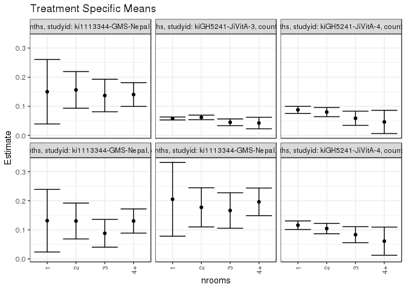

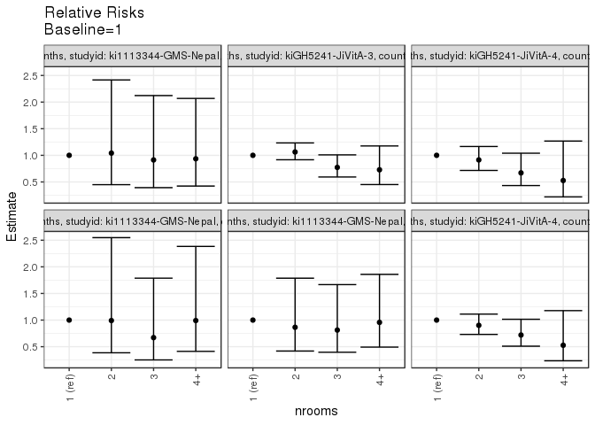

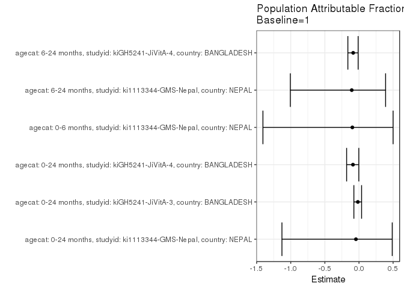

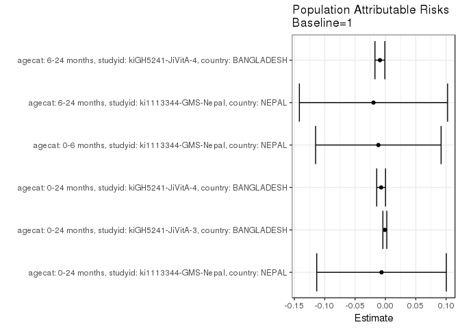

## Results Table

### Parameter: TSM

| agecat | studyid | country | intervention_level | baseline_level | estimate | ci_lower | ci_upper |
| --- | --- | --- | --- | --- | --- | --- | --- |
| 0-24 months | ki1113344-GMS-Nepal | NEPAL | 1 | NA | 0.1500000 | 0.0392509 | 0.2607491 |
| 0-24 months | ki1113344-GMS-Nepal | NEPAL | 2 | NA | 0.1562500 | 0.0932954 | 0.2192046 |
| 0-24 months | ki1113344-GMS-Nepal | NEPAL | 3 | NA | 0.1369863 | 0.0811668 | 0.1928058 |
| 0-24 months | ki1113344-GMS-Nepal | NEPAL | 4+ | NA | 0.1402878 | 0.0994296 | 0.1811460 |
| 0-24 months | kiGH5241-JiVitA-3 | BANGLADESH | 1 | NA | 0.0581370 | 0.0530348 | 0.0632392 |
| 0-24 months | kiGH5241-JiVitA-3 | BANGLADESH | 2 | NA | 0.0617990 | 0.0539441 | 0.0696540 |
| 0-24 months | kiGH5241-JiVitA-3 | BANGLADESH | 3 | NA | 0.0449583 | 0.0334317 | 0.0564849 |
| 0-24 months | kiGH5241-JiVitA-3 | BANGLADESH | 4+ | NA | 0.0423601 | 0.0226194 | 0.0621007 |
| 0-24 months | kiGH5241-JiVitA-4 | BANGLADESH | 1 | NA | 0.0876586 | 0.0755535 | 0.0997637 |
| 0-24 months | kiGH5241-JiVitA-4 | BANGLADESH | 2 | NA | 0.0801221 | 0.0642856 | 0.0959585 |
| 0-24 months | kiGH5241-JiVitA-4 | BANGLADESH | 3 | NA | 0.0587687 | 0.0344470 | 0.0830903 |
| 0-24 months | kiGH5241-JiVitA-4 | BANGLADESH | 4+ | NA | 0.0462107 | 0.0063080 | 0.0861135 |
| 0-6 months | ki1113344-GMS-Nepal | NEPAL | 1 | NA | 0.1315789 | 0.0240029 | 0.2391550 |
| 0-6 months | ki1113344-GMS-Nepal | NEPAL | 2 | NA | 0.1304348 | 0.0688252 | 0.1920443 |
| 0-6 months | ki1113344-GMS-Nepal | NEPAL | 3 | NA | 0.0882353 | 0.0405217 | 0.1359489 |
| 0-6 months | ki1113344-GMS-Nepal | NEPAL | 4+ | NA | 0.1304348 | 0.0888976 | 0.1719719 |
| 6-24 months | ki1113344-GMS-Nepal | NEPAL | 1 | NA | 0.2051282 | 0.0782889 | 0.3319675 |
| 6-24 months | ki1113344-GMS-Nepal | NEPAL | 2 | NA | 0.1774194 | 0.1101211 | 0.2447176 |
| 6-24 months | ki1113344-GMS-Nepal | NEPAL | 3 | NA | 0.1666667 | 0.1057442 | 0.2275891 |
| 6-24 months | ki1113344-GMS-Nepal | NEPAL | 4+ | NA | 0.1962963 | 0.1488779 | 0.2437147 |
| 6-24 months | kiGH5241-JiVitA-4 | BANGLADESH | 1 | NA | 0.1160515 | 0.1013280 | 0.1307750 |
| 6-24 months | kiGH5241-JiVitA-4 | BANGLADESH | 2 | NA | 0.1045908 | 0.0867658 | 0.1224159 |
| 6-24 months | kiGH5241-JiVitA-4 | BANGLADESH | 3 | NA | 0.0834971 | 0.0559570 | 0.1110371 |
| 6-24 months | kiGH5241-JiVitA-4 | BANGLADESH | 4+ | NA | 0.0611440 | 0.0127904 | 0.1094975 |

### Parameter: E(Y)

| agecat | studyid | country | intervention_level | baseline_level | estimate | ci_lower | ci_upper |
| --- | --- | --- | --- | --- | --- | --- | --- |
| 0-24 months | ki1113344-GMS-Nepal | NEPAL | NA | NA | 0.1435811 | 0.1153098 | 0.1718524 |
| 0-24 months | kiGH5241-JiVitA-3 | BANGLADESH | NA | NA | 0.0571830 | 0.0530902 | 0.0612758 |
| 0-24 months | kiGH5241-JiVitA-4 | BANGLADESH | NA | NA | 0.0805591 | 0.0719065 | 0.0892117 |
| 0-6 months | ki1113344-GMS-Nepal | NEPAL | NA | NA | 0.1199262 | 0.0925504 | 0.1473020 |
| 6-24 months | ki1113344-GMS-Nepal | NEPAL | NA | NA | 0.1854419 | 0.1537023 | 0.2171816 |
| 6-24 months | kiGH5241-JiVitA-4 | BANGLADESH | NA | NA | 0.1069508 | 0.0962252 | 0.1176764 |

### Parameter: RR

| agecat | studyid | country | intervention_level | baseline_level | estimate | ci_lower | ci_upper |
| --- | --- | --- | --- | --- | --- | --- | --- |
| 0-24 months | ki1113344-GMS-Nepal | NEPAL | 1 | 1 | 1.0000000 | 1.0000000 | 1.000000 |
| 0-24 months | ki1113344-GMS-Nepal | NEPAL | 2 | 1 | 1.0416667 | 0.4492003 | 2.415558 |
| 0-24 months | ki1113344-GMS-Nepal | NEPAL | 3 | 1 | 0.9132420 | 0.3929539 | 2.122414 |
| 0-24 months | ki1113344-GMS-Nepal | NEPAL | 4+ | 1 | 0.9352518 | 0.4228937 | 2.068359 |
| 0-24 months | kiGH5241-JiVitA-3 | BANGLADESH | 1 | 1 | 1.0000000 | 1.0000000 | 1.000000 |
| 0-24 months | kiGH5241-JiVitA-3 | BANGLADESH | 2 | 1 | 1.0629903 | 0.9165995 | 1.232761 |
| 0-24 months | kiGH5241-JiVitA-3 | BANGLADESH | 3 | 1 | 0.7733160 | 0.5929971 | 1.008466 |
| 0-24 months | kiGH5241-JiVitA-3 | BANGLADESH | 4+ | 1 | 0.7286252 | 0.4515037 | 1.175837 |
| 0-24 months | kiGH5241-JiVitA-4 | BANGLADESH | 1 | 1 | 1.0000000 | 1.0000000 | 1.000000 |
| 0-24 months | kiGH5241-JiVitA-4 | BANGLADESH | 2 | 1 | 0.9140244 | 0.7163606 | 1.166229 |
| 0-24 months | kiGH5241-JiVitA-4 | BANGLADESH | 3 | 1 | 0.6704266 | 0.4322652 | 1.039806 |
| 0-24 months | kiGH5241-JiVitA-4 | BANGLADESH | 4+ | 1 | 0.5271670 | 0.2191558 | 1.268071 |
| 0-6 months | ki1113344-GMS-Nepal | NEPAL | 1 | 1 | 1.0000000 | 1.0000000 | 1.000000 |
| 0-6 months | ki1113344-GMS-Nepal | NEPAL | 2 | 1 | 0.9913043 | 0.3856030 | 2.548436 |
| 0-6 months | ki1113344-GMS-Nepal | NEPAL | 3 | 1 | 0.6705882 | 0.2516216 | 1.787162 |
| 0-6 months | ki1113344-GMS-Nepal | NEPAL | 4+ | 1 | 0.9913043 | 0.4122431 | 2.383749 |
| 6-24 months | ki1113344-GMS-Nepal | NEPAL | 1 | 1 | 1.0000000 | 1.0000000 | 1.000000 |
| 6-24 months | ki1113344-GMS-Nepal | NEPAL | 2 | 1 | 0.8649194 | 0.4187277 | 1.786568 |
| 6-24 months | ki1113344-GMS-Nepal | NEPAL | 3 | 1 | 0.8125000 | 0.3961573 | 1.666400 |
| 6-24 months | ki1113344-GMS-Nepal | NEPAL | 4+ | 1 | 0.9569444 | 0.4926963 | 1.858635 |
| 6-24 months | kiGH5241-JiVitA-4 | BANGLADESH | 1 | 1 | 1.0000000 | 1.0000000 | 1.000000 |
| 6-24 months | kiGH5241-JiVitA-4 | BANGLADESH | 2 | 1 | 0.9012448 | 0.7305806 | 1.111776 |
| 6-24 months | kiGH5241-JiVitA-4 | BANGLADESH | 3 | 1 | 0.7194827 | 0.5095361 | 1.015935 |
| 6-24 months | kiGH5241-JiVitA-4 | BANGLADESH | 4+ | 1 | 0.5268694 | 0.2357734 | 1.177365 |

### Parameter: PAR

| agecat | studyid | country | intervention_level | baseline_level | estimate | ci_lower | ci_upper |
| --- | --- | --- | --- | --- | --- | --- | --- |
| 0-24 months | ki1113344-GMS-Nepal | NEPAL | 1 | NA | -0.0064189 | -0.1132232 | 0.1003854 |
| 0-24 months | kiGH5241-JiVitA-3 | BANGLADESH | 1 | NA | -0.0009540 | -0.0041847 | 0.0022767 |
| 0-24 months | kiGH5241-JiVitA-4 | BANGLADESH | 1 | NA | -0.0070995 | -0.0143588 | 0.0001597 |
| 0-6 months | ki1113344-GMS-Nepal | NEPAL | 1 | NA | -0.0116527 | -0.1150902 | 0.0917847 |
| 6-24 months | ki1113344-GMS-Nepal | NEPAL | 1 | NA | -0.0196863 | -0.1418369 | 0.1024643 |
| 6-24 months | kiGH5241-JiVitA-4 | BANGLADESH | 1 | NA | -0.0091007 | -0.0172727 | -0.0009287 |

### Parameter: PAF

| agecat | studyid | country | intervention_level | baseline_level | estimate | ci_lower | ci_upper |
| --- | --- | --- | --- | --- | --- | --- | --- |
| 0-24 months | ki1113344-GMS-Nepal | NEPAL | 1 | NA | -0.0447059 | -1.1291685 | 0.4874007 |
| 0-24 months | kiGH5241-JiVitA-3 | BANGLADESH | 1 | NA | -0.0166833 | -0.0748486 | 0.0383344 |
| 0-24 months | kiGH5241-JiVitA-4 | BANGLADESH | 1 | NA | -0.0881283 | -0.1810580 | -0.0025106 |
| 0-6 months | ki1113344-GMS-Nepal | NEPAL | 1 | NA | -0.0971660 | -1.4077031 | 0.5000325 |
| 6-24 months | ki1113344-GMS-Nepal | NEPAL | 1 | NA | -0.1061586 | -1.0062454 | 0.3901110 |
| 6-24 months | kiGH5241-JiVitA-4 | BANGLADESH | 1 | NA | -0.0850926 | -0.1629316 | -0.0124636 |